# Презентация по лаборатольной работе No.1

Операционные системы

Джаллох Ишмаил

Российский университет дружбы народов, Москва, Россия

Объединённый институт ядерных исследований, Дубна, Россия

02 март 2025

## Цель работы

Целью данной работы является приобретение практических навыков установки операционной системы на виртуальную машину, настройки минимально необходимых для дальнейшей работы сервисов.

## Задание

1. Создание виртуальной машины
2. Установка операционной системы
3. Работа с операционной системой после установки
4. Установка программного обеспечения для создания документации
5. Дополнительные задания

# Выполнение лабораторной работы

## Создание виртуальной машины

Virtualbox я устанавливала и настраивала при выполнении лабораторной работы в курсе “Архитектура компьютера и Операционные системы (раздел”Архитектура компьютера”)“, поэтому сразу открываю окно приложения (рис. @fig:001).

[figure not shown]

Окно Virtualbox

## Создание виртуальной машины

Нажимая “создать”, создаю новую виртуальную машину, указываю ее имя, путь к папке машины по умолчанию меня устраивает, выбираю тип ОС и версию (рис. @fig:002).

[figure not shown]

Создание виртуальной машины

## Создание виртуальной машины

Указываю объем основной памяти виртуальной машины размером 4096МБ (рис. @fig:003).

[figure not shown]

Указание объема памяти

## Создание виртуальной машины

Выбираю в Virtualbox настройку своей виртуальной машины. Перехожу в “Носители”, добавляю новый привод привод оптических дисков и выбираю скачанный образ операционной системы Fedora (рис. @fig:004).

[figure not shown]

Выбор образа оптического диска

## Создание виртуальной машины

Скачанный образ ОС был успешно выбран (рис. @fig:005).

[figure not shown]

Выбранный образ оптического диска

## Установка операционной системы

[figure not shown]

Выбор языка интерфейса

## Установка операционной системы

Раскладку клавиатуры выбираю и русскую, и английскую (рис. @fig:007).

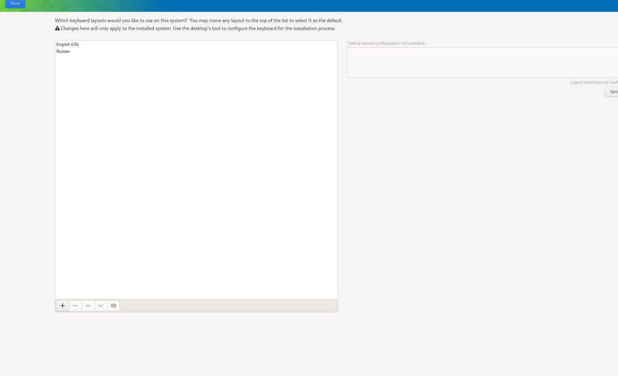

Выбор раскладки клавиатуры

## Установка операционной системы

Далее операционная система устанавливается. После установки нажимаю “завершить установку” (рис. @fig:008).

[figure not shown]

Завершение установки операционной системы

## Работа с операционной системой после установки

Нажимаю Win+Enter для запуска терминала и переключаюсь на роль супер-пользователя(рис. @fig:028).

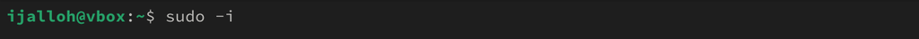

Запуск терминала

## Работа с операционной системой после установки

Обновляю все пакеты (рис. @fig:029).

[figure not shown]

Обновления

## Работа с операционной системой после установки

Устанавливаю программы для удобства работы в концсоли: tmux для открытия нескольких “вкладок” в одном терминале, mc в качестве файлового менеджера в терминале (рис. @fig:030).

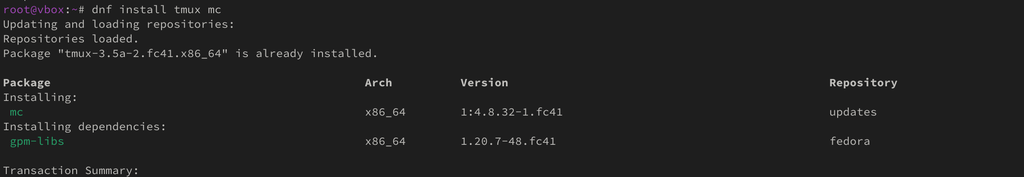

Установка tmux и mc

## Работа с операционной системой после установки

Устанавливаю программы для автоматического обновления (рис. @fig:031).

[figure not shown]

Установка программного обеспечения для автоматического обновления

## Работа с операционной системой после установки

Запускаю таймер (рис. @fig:032).

[figure not shown]

Запуск таймера

## Работа с операционной системой после установки

Перемещаюсь в директорию /etc/selinux, открываю md, ищу нужный файл (рис. @fig:033).

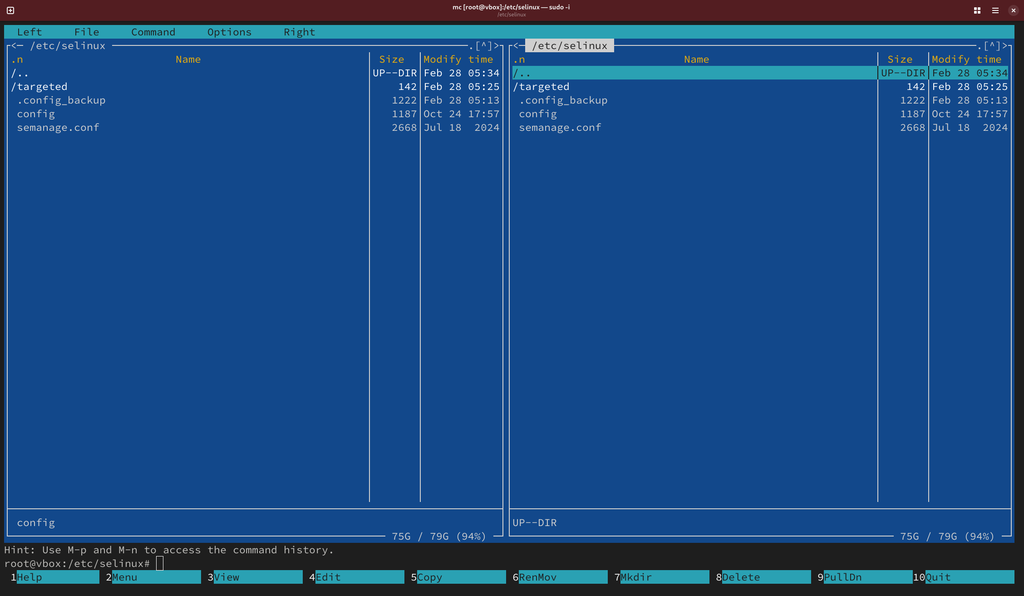

Поиск файла

## Работа с операционной системой после установки

Изменяю открытый файл: SELINUX=enforcing меняю на значение SELINUX=permissive (рис. @fig:034).

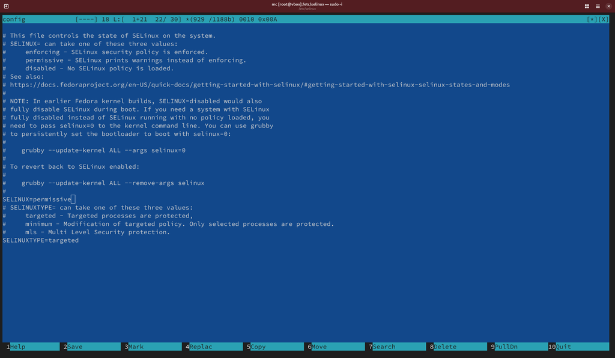

Изменение файла

## Работа с операционной системой после установки

Перезагружаю виртуальную машину (рис. @fig:037).

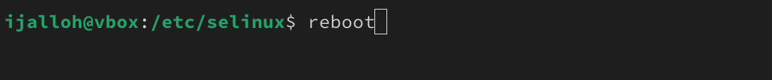

Перезагрузка виртуальной машины

## Работа с операционной системой после установки

Снова вхожу в ОС, снова запускаю терминал, запускюа терминальный мультиплексор (рис. @fig:038).

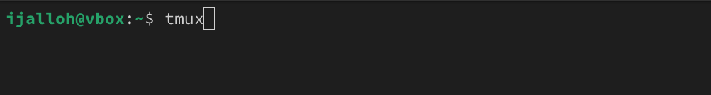

Запуск терминального мультиплексора

## Работа с операционной системой после установки

Переключаюсь на роль супер-пользователя (рис. @fig:039).

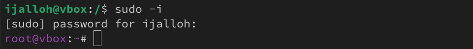

Переключение на роль супер-пользователя

## Работа с операционной системой после установки

Устанавливаю пакет dkms (рис. @fig:0340).

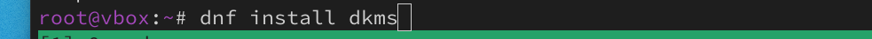

Установка пакета dkms

## Работа с операционной системой после установки

В меню виртуальной машины подключаю образ диска гостевой ОС и примонтирую диск с помощью утилиты mount (рис. @fig:041).

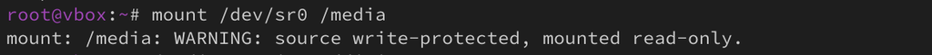

Примонтирование диска

## Работа с операционной системой после установки

Устанавливаю драйвера (рис. @fig:042).

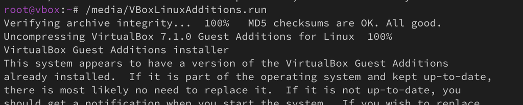

Установка драйвера

## Работа с операционной системой после установки

Перезагружаю виртуальную машину (рис. @fig:043).

[figure not shown]

Перезагрузка виртуальной машины

## Работа с операционной системой после установки

Перехожу в директорию /tc/X11/xorg.conf.d, открываю mc для удобства, открываю файл 00-keyboard.conf (рис. @fig:044).

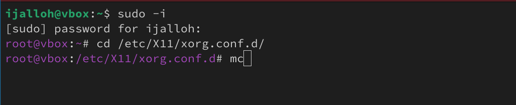

Поиск файла, вход в mc

## Работа с операционной системой после установки

Редактирую конфигурационный файл (рис. @fig:045).

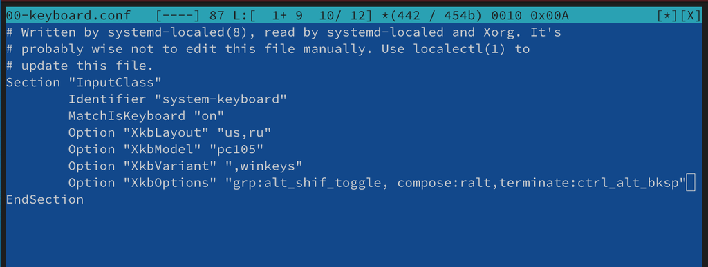

Редактирование файла

## Работа с операционной системой после установки

Перезагружаю виртуальную машину (рис. @fig:046).

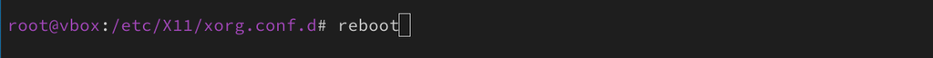

Перезагрузка виртуальной машины

## Установка программного обеспечения для создания документации

Запускаю терминал. Запускаю терминальный мультиплексор tmux, переключаюсь на роль супер-пользователя (рис. @fig:047).

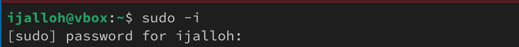

Переключение на роль супер-пользователя

## Установка программного обеспечения для создания документации

Устанавливаю pandoc с помощью утилиты dnf и флага -y, который автоматически на все вопросы системы отчевает “yes” (рис. @fig:048).

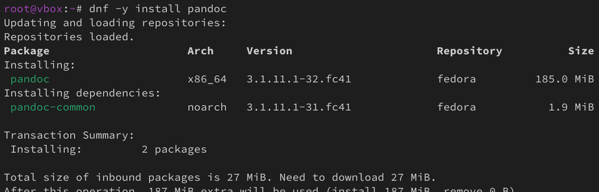

Установка pandoc

## Установка программного обеспечения для создания документации

Устанавливаю необходимые расширения для pandoc (рис. @fig:049).

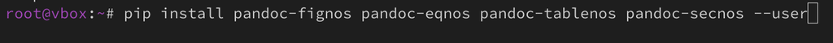

Установка расширения pandoc

## Установка программного обеспечения для создания документации

Устанавливаю дистрибутив texlive (рис. @fig:051).

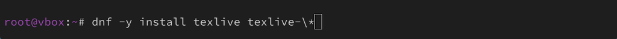

Установка texlive

## Выводы

При выполнении данной лабораторной работы я приобрела практические навыки установки операционной системы на виртуальную машину, а так же сделала настройки минимально необходимых для дальнейшей работы сервисов.

## Выполнение дополнительного задания

Ввожу в терминале команду dmesg, чтобы проанализировать последовательность загрузки системы (рис. @fig:053).

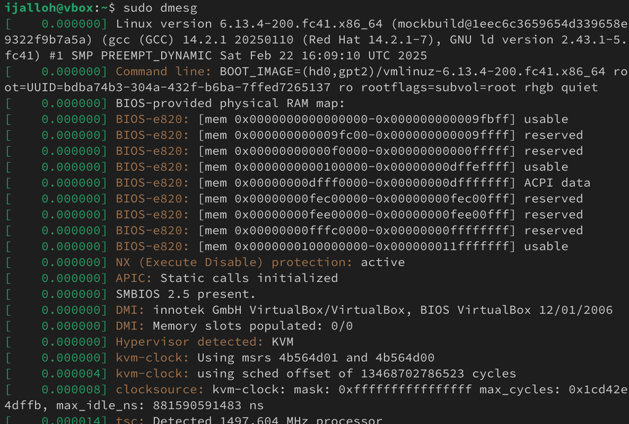

Анализ последовательности загрузки системы

## Выполнение дополнительного задания

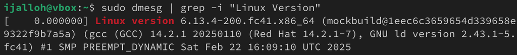

Поиск версии ядра

## Выполнение дополнительного задания

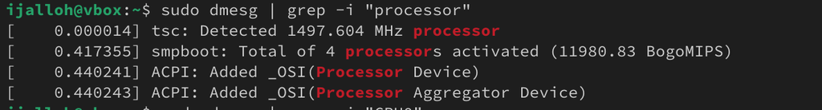

Поиск частоты процессора

## Выполнение дополнительного задания

Аналогично ищу модель процессора (рис. @fig:056).

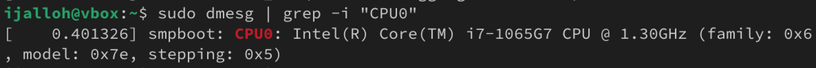

Поиск модели процессора

## Выполнение дополнительного задания

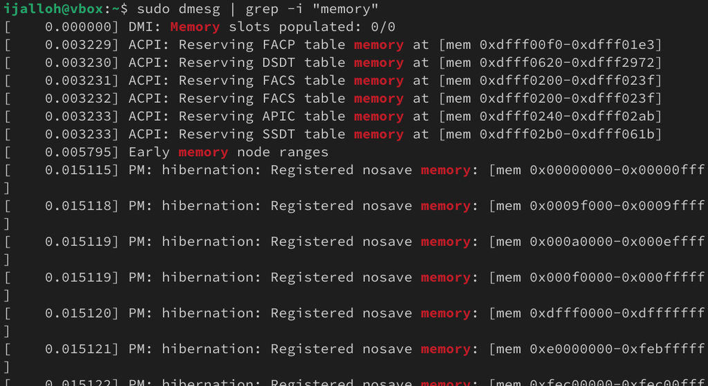

Поиск объема доступной оперативной памяти

## Выполнение дополнительного задания

Нахожу тип обнаруженного гипервизора (рис. @fig:058).

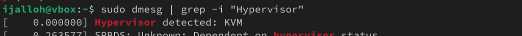

Поиск типа обнаруженного гипервизора

## Выполнение дополнительного задания

Последовательность монтирования файловых систем можно посмотреть, введя в поиск по результату dmesg слово mount (рис. @fig:060).

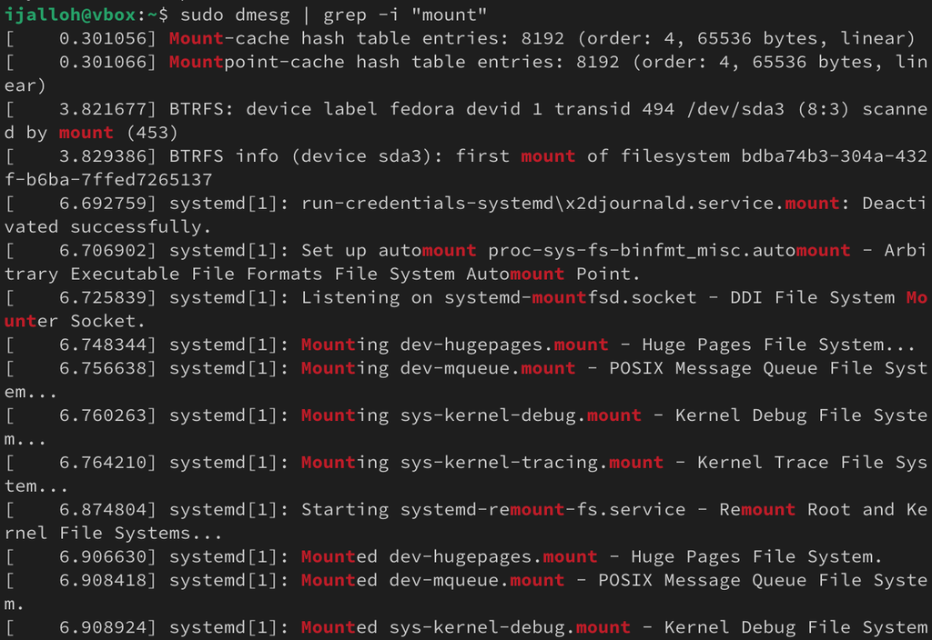

Последовательность монтирования файловых систем